# Project 2

Jake Brophy, Seungmin Lee, Angad Singh Shergill

2/11/2022

Jake Brophy UID: 305088618

Angad Singh Shergill UID: 204962102

Seungmin Lee UID: 905880427

# Introduction:

# Part a

```r
#Read in Data
df <- read.csv("SampleVar.csv")
df <- df[,c('unem', 'psei', "real_gdp_growth")]
#Convert to time series
df.ts <- ts(df, start = 1999, frequency=4)
library(forecast)
```

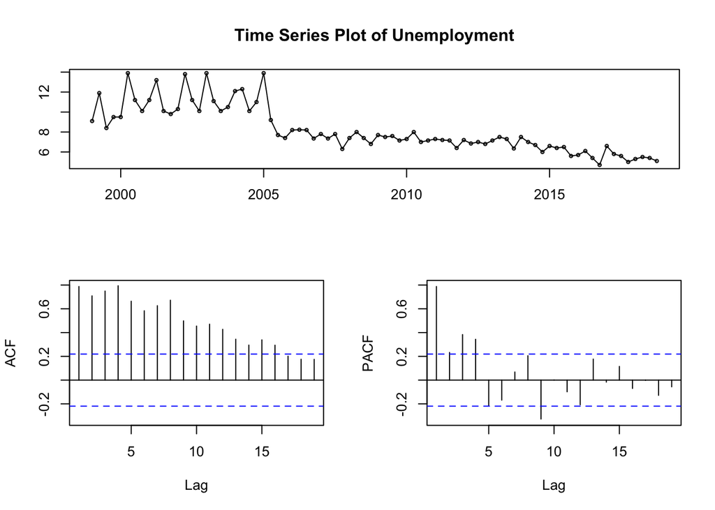

```r
#Time series plot
tsdisplay(df.ts[,"unem"], main = "Time Series Plot of Unemployment")
```

# Part b

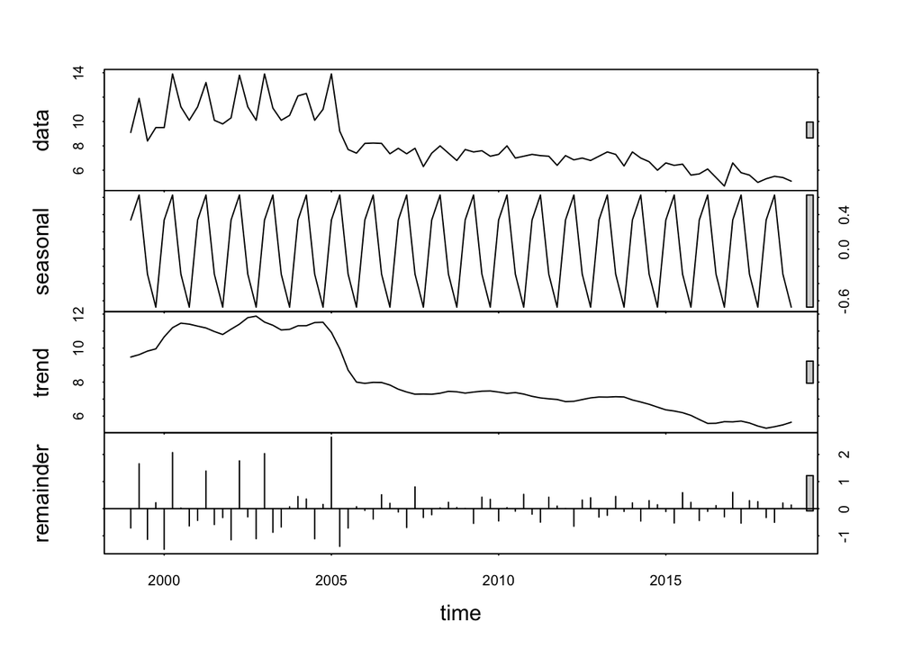

```r
#STL decomposition
plot(stl(df.ts[,"unem"], s.window="periodic"))
```

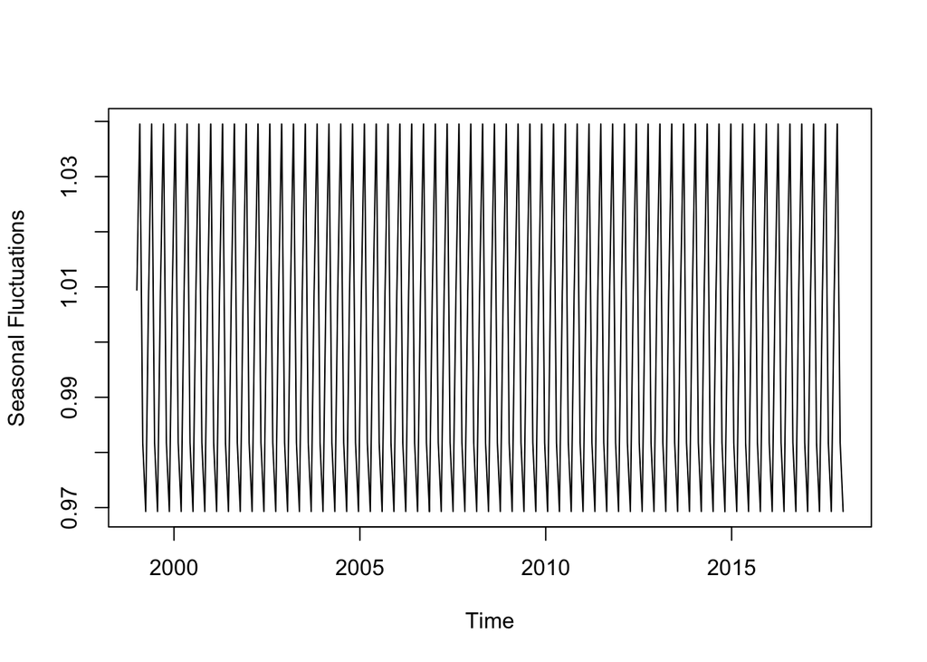

```r
library(forecast)
dcmp <- decompose(df.ts, "multiplicative")
dcms <- dcmp$seasonal
t.ylab <- seq(1999, 2018, length = length(dcms))
plot(t.ylab, dcms, ylab = "Seasonal Fluctuations", xlab = "Time",type = "l")
```

# Part c

```r
#Create trend variable
t <- seq(1999, 2018, length = length(df.ts[,"unem"]))
t2 <- -t
#Generate Arima model with trend, cycles, and seasonality
m1 <- Arima(df.ts[,"unem"],order=c(1,1,0),seasonal=list(order=c(2,0,0)), xreg = t2)
```

The model I picked was an Arima(1,1,0)(2,0,0) with an additional external regressor in the form of a negative linear trend. The cycles present in the data were taken care of by the Arma(1,0) component, which was necessary due to the serial correlation present in the original data, and the trend was taken care of by the Arima(1,1,0), as well as the included negative linear trend. It was necessary to include the I(1) component because the data did not appear to be covariance stationary, so taking the first difference made the data covariance stationary. The seasonal component of the data was taken care of by the S-Arma(2,0), which was necessary to include because of the previously discussed seasonality present in the data.

# Part e

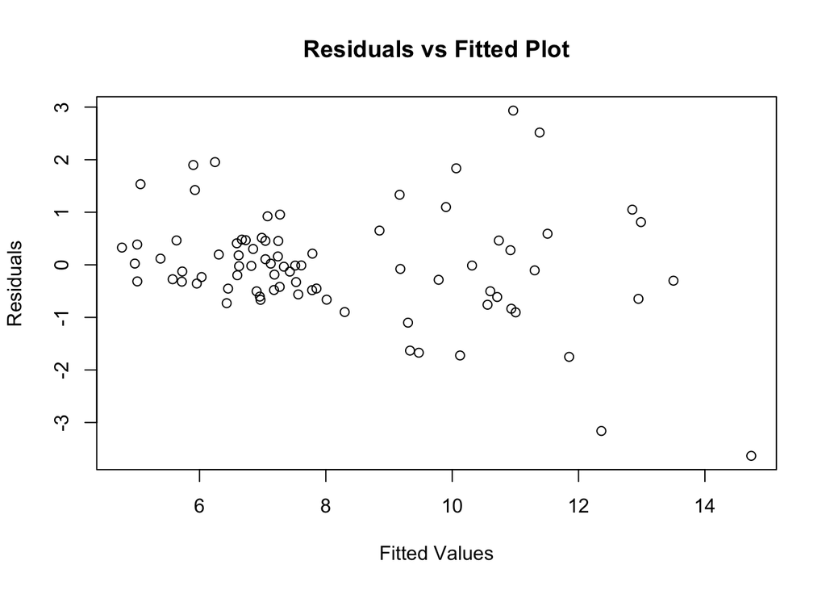

```r
#Make variable for residuals and fitted
res <- m1$residuals
res <- res[1:length(res)]
fit <- fitted(m1)
fit <- fit[1:length(fit)]
#Plot residuals vs fited
plot(fit, res, ylab = "Residuals", xlab = "Fitted Values", main = "Residuals vs Fitted Plot")
```

From the residuals vs fitted plot, we can see that the mean of residuals is approximately zero. However, there still appears to be a pattern in the residuals, which suggests that not all of the dynamics were taken out.

# Part f

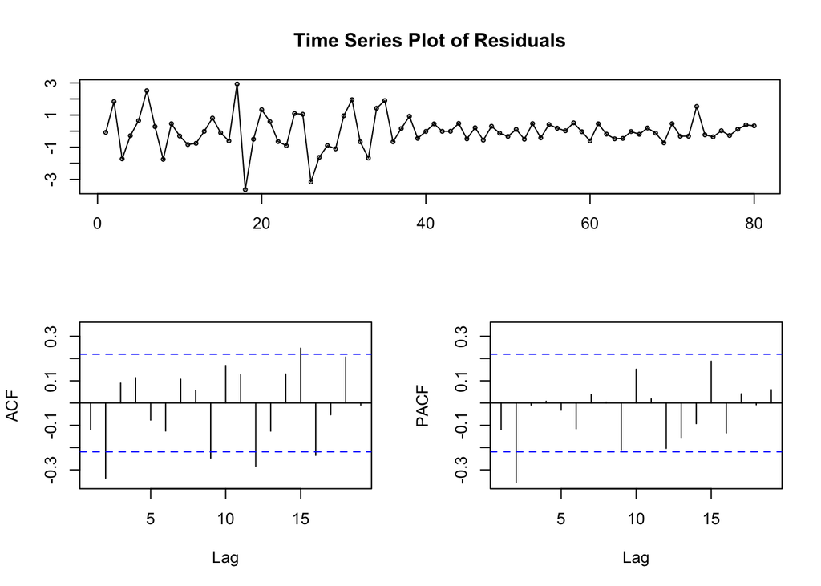

```r
#Look at ACF and PACF of residuals
tsdisplay(res, main = "Time Series Plot of Residuals")
```

We can still see some spikes and cycles in the ACF and PACF plot. This suggests that not all dynamics were taken out, which reinforces our analyses of the residuals.

# Part g

```r
library(strucchange)
```

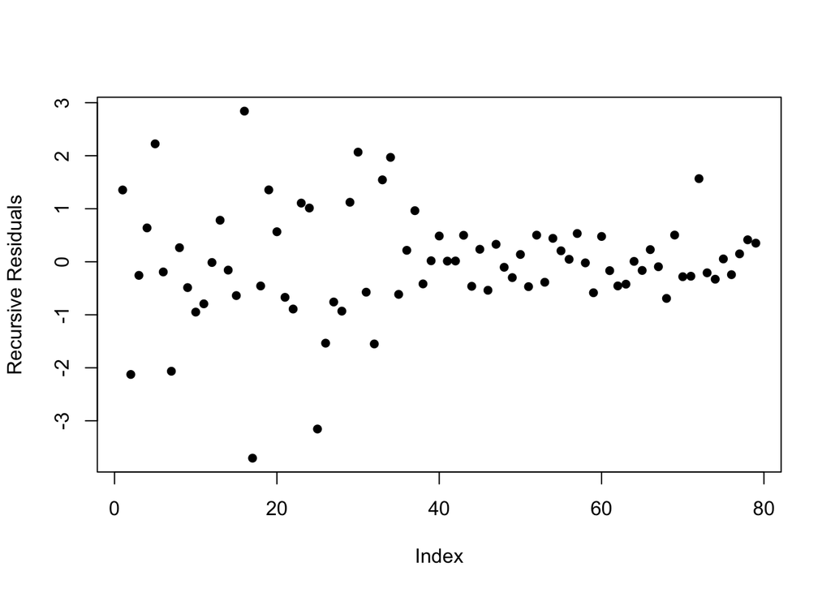

```r
y=recresid(m1$res~1)
#Plot recursive residuals
plot(y, pch=16,ylab="Recursive Residuals")
```

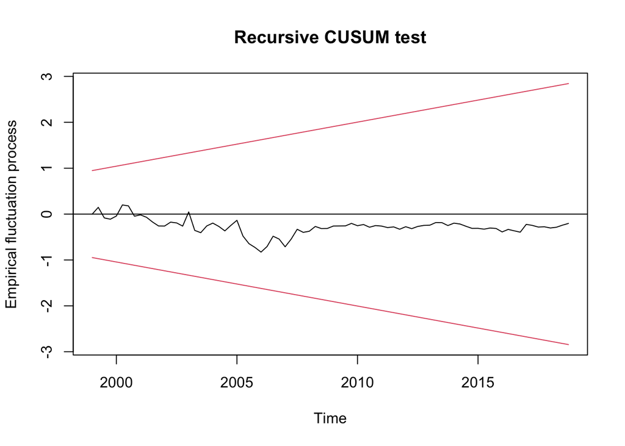

```r
#Plot recursive residuals with window for better interpretability
plot(efp(m1$res~1, type = "Rec-CUSUM"))
```

We can see from the initial investigation of CUSUM it appears that our model might break at lower frequencies. However, when plotted, we can see that the residuals remain within the two bands, which may suggest that the possible breakage at lower frequencies is not statistically significant.

# Part h

```r
#Look at model summary
summary(m1, diagnostics = TRUE)
```

```
## Series: df.ts[, "unem"]
## Regression with ARIMA(1,1,0)(2,0,0)[4] errors
##
## Coefficients:
##           ar1    sar1    sar2     xreg
##       -0.3714  0.2834  0.4972  -0.0439
## s.e.   0.1041  0.0937  0.1021   1.2771
##
## sigma^2 estimated as 1.118:  log likelihood=-116.42
## AIC=242.83   AICc=243.66   BIC=254.68
##
## Training set error measures:
##                       ME     RMSE       MAE        MPE     MAPE     MASE
## Training set -0.02098348 1.023659 0.7092273 -0.6981106 8.228371 0.838278
##                    ACF1
## Training set -0.1203154
```

# Part i

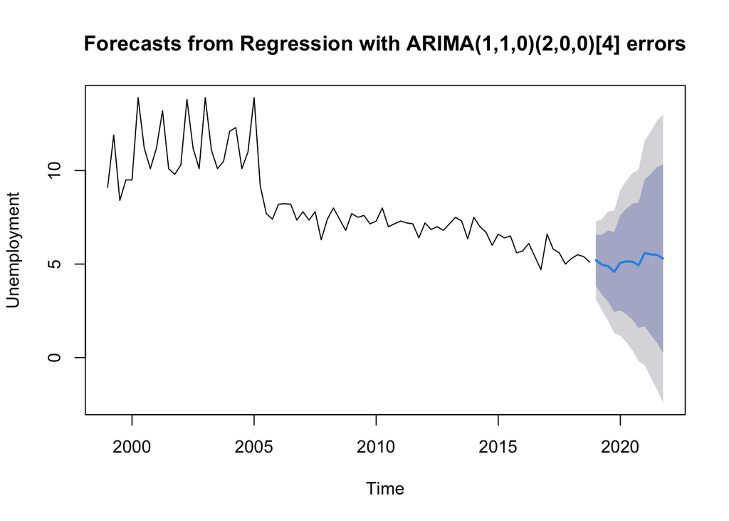

```r
#Create external regressor with length 12 for prediction
t3 <- seq(1999, 2018, length = 12)
t4 <- -t3
#Plot the forecast of our model
plot(forecast(m1, xreg = t4), interval = "prediction", ylab = "Unemployment", xlab = "Time")
```

# Part j

```r
library(rpart)
#conduct train test split
train <- window(df.ts[,"unem"], start = c(1999), end = c(2016))
test <- window(df.ts[,"unem"], start = c(2016, 1))
#Create external regressor for train test split
t.train <- seq(1999, 2016, length = length(train))
t.train2 <- -t.train
t.test <- seq(1999, 2016, length = 12)
t.test2 <- -t.test

#generate forecasts

#Our model
mari <- Arima(train,order=c(1,1,0),seasonal=list(order=c(2,0,0)), xreg = t.train2)
mari.t <- forecast(mari, train, xreg = t.test2, h = 12)

#Auto generated model
arima.t <- auto.arima(train)
ari.f <- forecast(arima.t, train, h = length(test))

#ETS model
ets.t <- ets(train)
ets.f <- forecast.ets(ets.t, h = length(test))

#HoltWinters Model
hw.t <- HoltWinters(train)
hw.p <- forecast(hw.t, h = length(test))

#Evaluating accuracies of each prediction
holt.acc <- accuracy(hw.p, test)["Test set","MAPE"]
ets.acc <- accuracy(ets.f, test)["Test set","MAPE"]
ari.acc <- accuracy(ari.f, test)["Test set","MAPE"]
mari.acc <- accuracy(mari.t, test)["Test set","MAPE"]

#Putting accuracy in a table
tab <- matrix(c(holt.acc, ets.acc, ari.acc, mari.acc), ncol = 1)
colnames(tab) <- "MAPE"
rownames(tab) <- c("Holt Winters", "ETS", "ARIMA(0,1,1)(0,0,2)", "ARIMA(1,1,0)(2,0,0)")
tab
```

```
##                          MAPE
## Holt Winters         9.233555
## ETS                  7.770702
## ARIMA(0,1,1)(0,0,2)  7.447268
## ARIMA(1,1,0)(2,0,0) 15.300514
```

We can see from our table that the auto generated ARIMA model had the best MAPE, followed by exponential smoothing, then HoltWinters, and then by the ARIMA model we generated.

# Part k

```r
#Concatenate every mean
pred.df <- cbind(ets.f$mean, ari.f$mean, hw.p$mean, mari.t$mean)
pred.df <- pred.df[1:12,]
#Take the mean of every row which is each period's prediction
meanpred <- rowMeans(pred.df)
#Create a dataframe with test set and combined prediction
test.df <- data.frame(test, meanpred)
#Calculate MAPE
mean.acc <- mean(abs((test.df$test- test.df$meanpred)/test.df$test)) * 100
#Add to the previous table
tab2 <- matrix(c(holt.acc, ets.acc, ari.acc, mari.acc, mean.acc), ncol = 1)
colnames(tab2) <- "MAPE"
rownames(tab2) <- c("Holt Winters", "ETS", "ARIMA(0,1,1)(0,0,2)", "ARIMA(1,1,0)(2,0,0)",
                   "Combination")
#Print out table
tab2
```

```
##                          MAPE
## Holt Winters         9.233555
## ETS                  7.770702
## ARIMA(0,1,1)(0,0,2)  7.447268
## ARIMA(1,1,0)(2,0,0) 15.300514
## Combination          7.403286
```

The Combination of every forecast performs better than every model with an MAPE of 7.403286, only slightly better than the ARIMA(0,1,1)(0,0,2) model.

# Part l

```r
#Create dataframe with variables of interest
df.df <- data.frame(df.ts[,c("real_gdp_growth","unem")])
#Rename column names
colnames(df.df) <- c("GDP", "Unem")
library(vars)
#Evaluate best VAR model
VARselect(df.df)
```

```
## $selection
## AIC(n)  HQ(n)  SC(n) FPE(n)
##      4      4      1      4
##
## $criteria
##               1         2         3         4         5         6         7
## AIC(n) 0.887058 0.8615157 0.6375455 0.5310598 0.5805428 0.6459184 0.6731553
## HQ(n)  0.963612 0.9891057 0.8161714 0.7607218 0.8612407 0.9776523 1.0559252
## SC(n)  1.079786 1.1827293 1.0872445 1.1092443 1.2872128 1.4810738 1.6367962
## FPE(n) 2.428231 2.3678991 1.8943710 1.7056088 1.7964182 1.9244495 1.9870450
##                8         9        10
## AIC(n) 0.6663433 0.6345542 0.7259485
## HQ(n)  1.1001492 1.1193961 1.2618264
## SC(n)  1.7584696 1.8551659 2.0750457
## FPE(n) 1.9860489 1.9395605 2.1469043
```

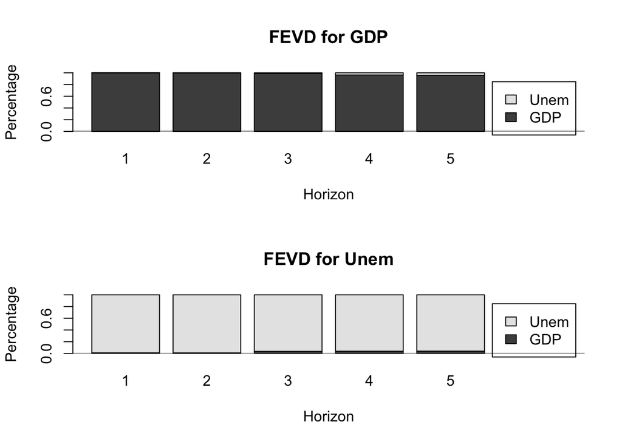

```r
#Generate VAR(4) model
var1 <- VAR(df.df, p = 4)
#Plot FEVD
plot(fevd(var1, n.ahead = 5))
```

```r
#Print summary of model
summary(var1)
```

```
##
## VAR Estimation Results:
## =========================
## Endogenous variables: GDP, Unem
## Deterministic variables: const
## Sample size: 76
## Log Likelihood: -224.523
## Roots of the characteristic polynomial:
## 0.991 0.8341 0.8341 0.736 0.736 0.4794 0.4794  0.17
## Call:
## VAR(y = df.df, p = 4)
##
##
## Estimation results for equation GDP:
## ====================================
## GDP = GDP.l1 + Unem.l1 + GDP.l2 + Unem.l2 + GDP.l3 + Unem.l3 + GDP.l4 + Unem.l4 + const
##
##         Estimate Std. Error t value Pr(>|t|)
## GDP.l1   0.79256    0.12024   6.592 8.09e-09 ***
## Unem.l1 -0.06547    0.11846  -0.553  0.58234
## GDP.l2  -0.10334    0.15266  -0.677  0.50077
## Unem.l2 -0.08187    0.12053  -0.679  0.49931
## GDP.l3  -0.03496    0.15282  -0.229  0.81977
## Unem.l3 -0.11348    0.11538  -0.984  0.32888
## GDP.l4  -0.10313    0.11512  -0.896  0.37354
## Unem.l4  0.12601    0.11332   1.112  0.27015
## const    3.48837    1.05005   3.322  0.00145 **
## ---
## Signif. codes:  0 '***' 0.001 '**' 0.01 '*' 0.05 '.' 0.1 ' ' 1
##
##
## Residual standard error: 1.201 on 67 degrees of freedom
## Multiple R-Squared: 0.5862,  Adjusted R-squared: 0.5368
## F-statistic: 11.86 on 8 and 67 DF,  p-value: 2.321e-10
##
##
## Estimation results for equation Unem:
## =====================================
## Unem = GDP.l1 + Unem.l1 + GDP.l2 + Unem.l2 + GDP.l3 + Unem.l3 + GDP.l4 + Unem.l4 + const
##
```

[output cut: 14 more lines]

```
## Residual standard error: 1.067 on 67 degrees of freedom
## Multiple R-Squared: 0.8134,  Adjusted R-squared: 0.7911
## F-statistic:  36.5 on 8 and 67 DF,  p-value: < 2.2e-16
##
##
##
## Covariance matrix of residuals:
##          GDP    Unem
## GDP   1.4417 -0.1291
## Unem -0.1291  1.1380
##
## Correlation matrix of residuals:
##          GDP    Unem
## GDP   1.0000 -0.1008
## Unem -0.1008  1.0000
```

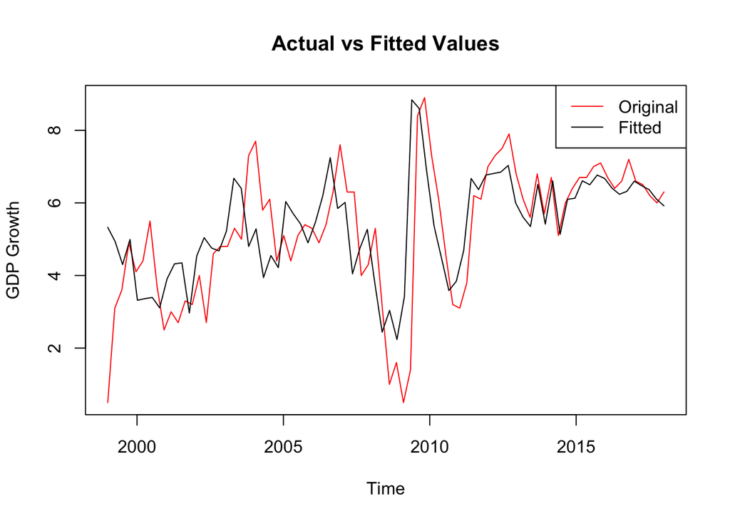

```r
#Pull out fitted values of Var model
fit <- fitted(var1)
#Generate sequences for y values of fitted vs real graph of GDP
t.yvalue1 <- seq(1999,2018, length = length(fit[,"GDP"]))
t.yvalue2 <- seq(1999,2018, length = length(df.ts[,"real_gdp_growth"]))
#Plot Fitted vs real values
plot(t.yvalue2, df.ts[,"real_gdp_growth"], type = "l", col = "red", ylab = "GDP Growth",
     xlab = "Time", main = "Actual vs Fitted Values")
lines(t.yvalue1, fit[,"GDP"], type = "l")
legend(x = "topright", legend = c("Original", "Fitted"), col = c("red", "black"),
       lty = c(1))
```

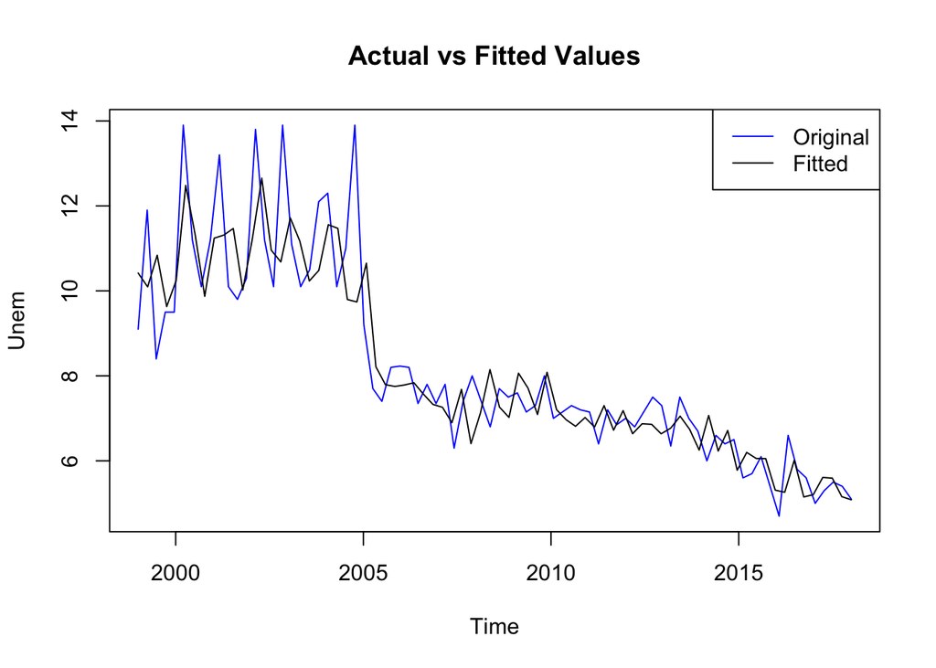

```r
#Generate sequences for y values of fitted vs real graph of Unemployment
t.yvalue3 <- seq(1999,2018, length = length(fit[,"Unem"]))
t.yvalue4 <- seq(1999,2018, length = length(df.ts[,"unem"]))
#Plot GDP fitted vs actual values
plot(t.yvalue4, df.ts[,"unem"], type = "l", col = "blue", ylab = "Unem",
     xlab = "Time", main = "Actual vs Fitted Values")
lines(t.yvalue3, fit[,"Unem"], type = "l")
legend(x = "topright", legend = c("Original", "Fitted"), col = c("blue", "black"),
       lty = c(1))
```

We can see from the FEVD that neither series plays a large role in determining the future value of the other. We do see that GDP plays a role influencing the future value of unemployment earlier than unemployment does for GDP. In the FEVD of unemployment growth, we can see that GDP begins affecting unemployment at period 3 and then stays fairly constant through period 5, while in the GDP FEVD, unemployment is not significant until period 4.

From the fitted vs actual plot we can see that the model matched the data fairly well with the exceptions of periods with large fluctuations which it tended to underestimate.

# Part m

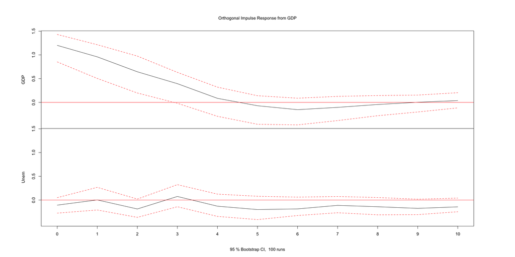

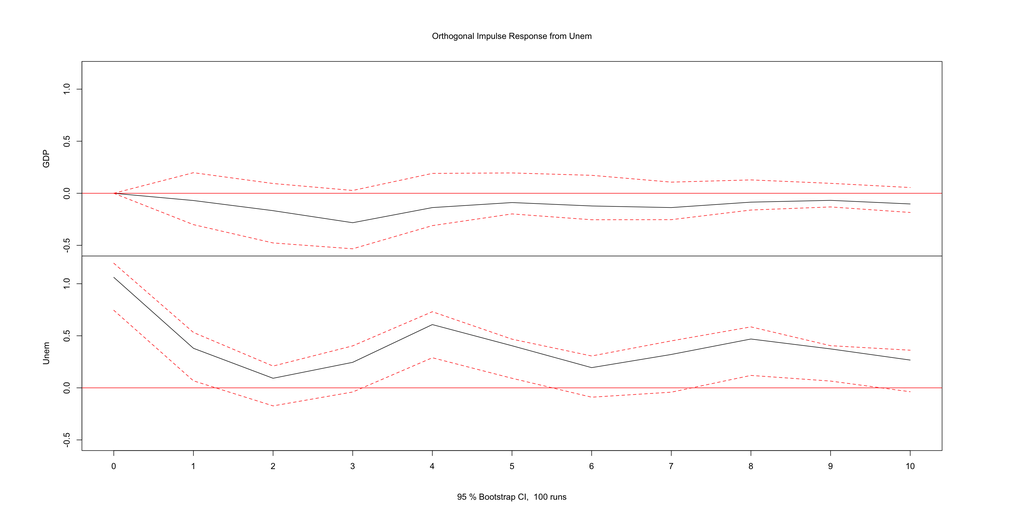

```r
#Plot the irf of the VAR(4) model
plot(irf(var1))
```

The irf plots shows that unemployment is positively affected by a one standard deviation unemployment shock and unemployment spikes regularly with decreased magnitude and then levels out. A shock in GDP causes an initial slight decrease in unemployment, but unemployment then evens out out to a level slightly below the initial level.

Similarly, the irf plot shows that and initial shock to GDP causes a sharp increase in GDP that eventually returns to the previous level. An unemployment shock initially causes GDP to decrease, then spike and eventually return to a level that is slightly lower than the original.

# Part n

```r
#Conduct grangertest on our two variables
grangertest(df.df$GDP~df.df$Unem)
```

```
## Granger causality test
##
## Model 1: df.df$GDP ~ Lags(df.df$GDP, 1:1) + Lags(df.df$Unem, 1:1)
## Model 2: df.df$GDP ~ Lags(df.df$GDP, 1:1)
##   Res.Df Df      F Pr(>F)
## 1     76
## 2     77 -1 1.5999 0.2098
```

```r
grangertest(df.df$Unem~df.df$GDP)
```

```
## Granger causality test
##
## Model 1: df.df$Unem ~ Lags(df.df$Unem, 1:1) + Lags(df.df$GDP, 1:1)
## Model 2: df.df$Unem ~ Lags(df.df$Unem, 1:1)
##   Res.Df Df      F Pr(>F)
## 1     76
## 2     77 -1 2.6863 0.1053
```

Since the p values are not significant i.e- less than 5%, we fail to reject the null in both cases and therefore we can say neither variable causes the other.

# Part o

```r
library(vars)
#Train test split
train2 <- window(df.ts[,c("unem","real_gdp_growth")], start = c(1999), end = c(2016))
train2.df <- data.frame(train2)
test2 <- window(df.ts[,c("unem","real_gdp_growth")], start = c(2016, 1))
test2.df <- data.frame(test2)
#Generate Var model on train set
var.1t <- VAR(train2.df, p = 4)
p.var <- predict(var.1t, train2.df, h=12, se.fit = TRUE, n.ahead = length(test), interval = "prediction")
#Pull out the individual unemployment and GDP fitted values
var.u <- p.var[[1]][['unem']][,1]
var.gdp <- p.var[[1]][['real_gdp_growth']][,1]
#Calculate MAPE
mean.u <- mean(abs((var.u- test2.df$unem)/var.u)) * 100
mean.gdp <- mean(abs((var.gdp- test2.df$real_gdp_growth)/var.gdp)) * 100
#Add values to the previous table
tab3 <- matrix(c(holt.acc, ets.acc, ari.acc, mari.acc, mean.acc, mean.u, mean.gdp), ncol = 1)
colnames(tab3) <- "MAPE"
rownames(tab3) <- c("Holt Winters", "ETS", "ARIMA(0,1,1)(0,0,2)", "ARIMA(1,1,0)(2,0,0)",
                   "Combination", "VAR(Unem)", "VAR(GDP)")
#Print table
tab3
```

```
##                          MAPE
## Holt Winters         9.233555
## ETS                  7.770702
## ARIMA(0,1,1)(0,0,2)  7.447268
## ARIMA(1,1,0)(2,0,0) 15.300514
## Combination          7.403286
## VAR(Unem)            5.461239
## VAR(GDP)            12.970816
```

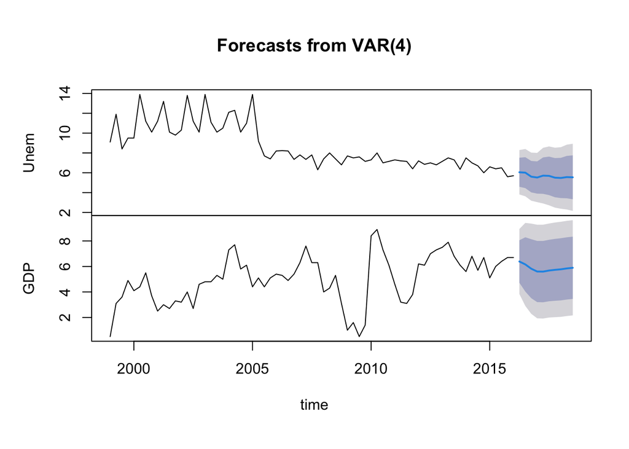

```r
#Rename columns
colnames(train2) <- c("Unem", "GDP")
#Plot the forecast
plot(forecast(VAR(train2, p = 4)))
```

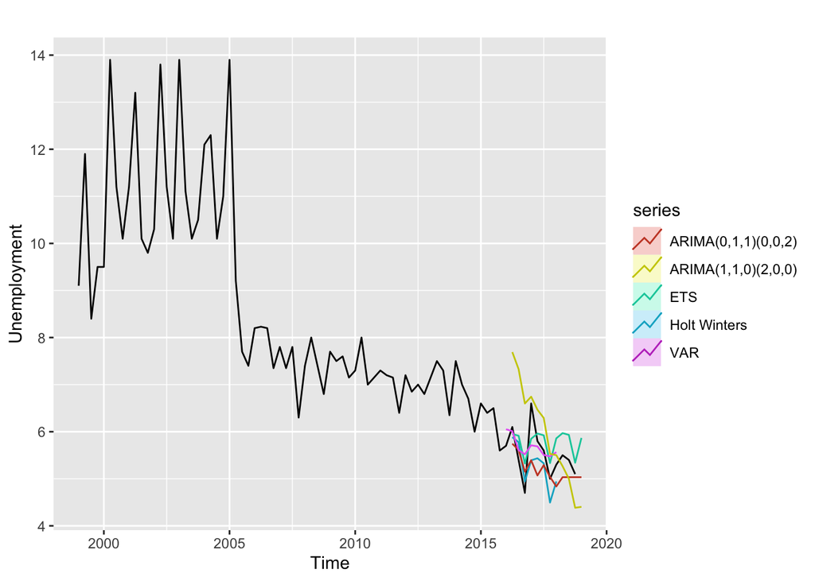

```r
#Convert predictions to timeseries for use in autoplot
var.u.ts <- ts(var.u, start = 2016, end = 2018, frequency = 4)
Unemployment <- df.ts[,"unem"]
#Plot the VAR model predictions vs the other models we tried vs the actual values
autoplot(Unemployment) +
  autolayer(forecast(hw.t), series = "Holt Winters", PI = FALSE)+
  autolayer(ari.f, series = "ARIMA(0,1,1)(0,0,2)", PI = FALSE) +
  autolayer(ets.f, series = "ETS", PI = FALSE) +
  autolayer(var.u.ts, series = "VAR") +
  autolayer(mari.t, series = "ARIMA(1,1,0)(2,0,0)", PI = FALSE)
```

We can see that in contrast to the other models, VAR also produces a forecast for the other variable of interest, GDP. We can also see that it has the lowest MAPE of every model we have tried so far, suggesting that it is the most accurate out of any model we have tried so far. This finding is then reinforced by the predicted values vs the actual test set, which shows VAR produces a forecast that is closest to the real value.

# Conclusion

The unemployment rate is one of the important economic indicators because it measures the underutilization of the labor supply and contains valuable information on a country’s labor market situation. In this project, we conducted a time series analysis and forecast the data using ARIMA, Holt-Winters, ETS model. Also, we fit VAR model using unemployment and real GDP growth and predict the future unemployment in the Philippines on a quarterly basis using this VAR model.

First investigation showed that the data had a slight upward trend before 2005 because of new entrants that joined the labor force and the slump in employment in the agriculture sector(1). The data had a major fall between 2005 to 2006 due to the millions of jobs created within that year(2) and new unemployment definition(3). Since 2006, the data have a downward trend and clear seasonal patterns.

We chose ARIMA(1,1,0)(2,0,0) model for estimating and forecasting the unemployment rate in the Philippines because of seasonality and non-stationality. From the respective residuals vs fitted values plot, the ARIMA model which we are using is not enough because the spread of the residuals is increasing and there is a chance that the data is heteroskedasticity, which may suggest that Philippines’ labor market situation has changed. Also from the ACF and PACF plot, we can see that there are some cyclic dynamics left.

Impulse response functions plot suggests that GDP mostly negatively influence unemployment but the magnitude is very small.

The unemployment rate is considered as a lagging indicator and closely related with real GDP growth. However, from a Granger-Causality test, we can’t reject $H_0$ both of cases with p-values 0.2098 and 0.1053. That is, GDP doesn’t have a great influence in the movements of the unemployment rate in the Philippines and vice versa.

We forecast the data using VAR(4) model. As a result, VAR(unem) model performs best with the lowest MAPE(5.461) and forecast a downward trend for next 3 years.

In conclusion, we hope that this project aids to have a better understanding of the unemployment rate to help solving the unemployment in the Philippines. For future work, we could fit VAR model and forecast the data using other variables such as PSEI, population, inflation rate and GNI and different frequency. Also, for predictions, future work could improve our fit and prediction by using more complicated models like the autoregressive conditional heteroskedasticity model to deal with changing spread of residuals.

Reference (1) Urrutia, J. D., Tampis, R. L., & Atienza, J. E. (2017). An Analysis on the Unemployment Rate in the Philippines: A Time Series Data Approach. In Journal of Physics: Conference Series (Vol. 820, Issue 1, p. 012008). IOP Publishing, 5p. https://iopscience.iop.org/article/10.1088/1742-6596/820/1/012008/meta

2. ) Urrutia, J. D., Tampis, R. L., & Atienza, J. E. (2017). An Analysis on the Unemployment Rate in the Philippines: A Time Series Data Approach. In Journal of Physics: Conference Series (Vol. 820, Issue 1, p. 012008). IOP Publishing, 6p.
3. CARMELITA N. ERICTA, (2005). Philippine Labor Force Survey October 2005. Philippine Statistics Authority. Retrieved February 19, 2022, from

https://psa.gov.ph/content/philippine-labor-force-survey-october-2005-preliminary-results

https://iopscience.iop.org/article/10.1088/1742-6596/820/1/012008/meta

https://psa.gov.ph/statistics/survey/labor-and-employment/labor-force-survey/title/Employment%20Situation%20in%20April%202020

https://ilostat.ilo.org/resources/concepts-and-definitions/description-unemployment-rate/

https://www.thebalance.com/unemployment-rate-3305744

https://www.thebalance.com/lagging-economic-indicators-list-index-and-top-3-3305860